How to create applications  
using Shiny

ISGlobal

Barcelona, February 13-14th 2018

Part V: Advanced issues

### Outline

**Part V: Advanced issues**

- `observe` and `observeEvent` functions.
- Updating elements
- Reactive variables
- `hide`, `show`, `toogle` and `disable` functions.

observe and observeEvent functions

### observeEvent

- The **`observeEvent`** function is meant to execute instructions inside the Server section when **one** element is changed/updated.
- All the code inside `observeEvent` will be exectued only if this element is changed.

```r
server <- function(input, output){
  ...
  observeEvent(input$element,{
    ...
    instructions
    ...
  })
  ...
}
```

### Example: Add a row in a stored data frame.

```r
# initiate with an empty data.frame
data <- data.frame(name = character(), age = numeric())
save(data, file="data.rda")

ui <- fluidPage(
  textInput("name", "Name", ""),
  numericInput("age", "Age", NA),
  actionButton("add", "Add")
)

server <- function(input, output){
  observeEvent(input$intro,{
    load("data.RData")
    newrow <- data.frame(name=input$name, age=input$age)
    data <- rbind(datos, newrow)
    save(datos, file="data.RData")
  })

}

shinyApp(ui, server)
```

Check how in “data.rda” new rows are being added.

### observe

- The first argument of `observeEvent` function is a single element.
- But, what happens if you desire to execute the instructions if one out of **several** elements change?
- Then **`observe`** function is used instead of `observeEvent`. You can use `isolate`.

```r
server <- function(input, output){
  ...
  observe({
    input$element1
    input$element2
    isolate({
      instructions
    })
  })
  ...
}
```

### Example

The code is executed when “age” or “chol” inputs elements are udpated.

```r
library(shinyFeedback)

ui <- fluidPage(
  useShinyFeedback(),

  numericInput("age", "Age", NA),
  numericInput("chol", "Cholesterol", NA)

)

server <- function(input, output) {

  observe({
   feedback("age", condition=input$age<30,
      text="Age must be > 30", color="red")
   feedback("chol", condition=input$chol>1000,
      text="Cholesterol must be < 1000", color="red")
  })

}

shinyApp(ui, server)
```

Updating elements

### Updating elements

- Unlike `uiOUtput / renderUI`, using the **`update***`** functions only those specified arguments are modified and the others remain as they are.
- **`update***`** functions are used inside Server section.
- Specifically, they are called inside `observe` or `observeEvent`.
- Note the argument **`session`** when defining Server function.

| Initialization | Update | Modifiable arguments |
| --- | --- | --- |
| `textInput` | `updateTextInput` | `label`, `value` |
| `numericInput` | `updateNumericInput` | `label`, `value` |
| `checkboxInput` | `updateCheckboxInput` | `label`, `value` |
| `radioButtons` | `updateRadioButtons` | `label`, `choices`, `selected`, `inline` |
| `selectInput` | `updateSelectInput` | `label`, `choices`, `selected` |
| `sliderInput` | `updateSliderInput` | `label`, `value`, `min`, `max`, `step` |
| `actionButton` | `--` | `--` |
| `bsButton {shinyBS}` | `updateButton` | `label`, `icon`, `style`, `disabled` |

### Example: variable list

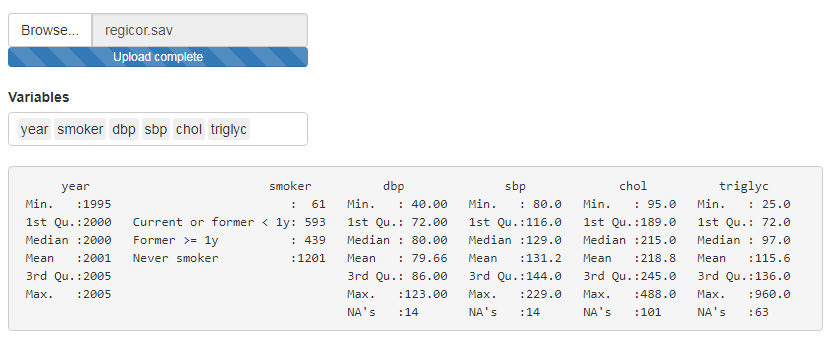

```r
library(Hmisc)

ui <- fluidPage(
  fileInput("file", ""),

  selectInput("vars", "Variables", choices=NULL,
              multiple=TRUE),

  verbatimTextOutput("summary")
)

server <- function(input, output, session){
  dat <- reactive({
    if (is.null(input$file))
      return(invisible(NULL))
    spss.get(input$file$datapath)
  })
  output$summary <- renderPrint({
    summary(dat()[,input$vars])
  })

  observe({
    updateSelectInput(session, "vars",
                      choices = names(dat()))
  })

}

shinyApp(ui, server)
```

**Exercise**: use renderUI and uiOutput

### Example 2: Button

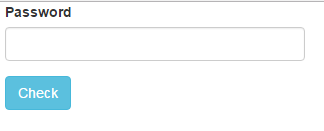

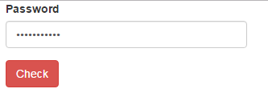

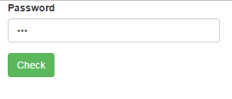

```r
library(shinyBS)

ui <- fluidPage(
  passwordInput("pass", "Password"),
  bsButton("check", "Check", style="info")
)

server <- function(input, output, session){

  observeEvent(input$check, {
    if (input$pass=='')
      updateButton(session, "check", style="warning")
    else {
      if (input$pass=='123')
        updateButton(session, "check", style="success")
      else
        updateButton(session, "check", style="danger")
    }
  })

}

shinyApp(ui, server)
```

Reactive variables

### Reactive variables

- **Reactive variables** are objects whose values are modified in a “reactive” way
- They exists inside the server section.
- Every *reactive values* type object is an element of a list which is iniciated using **`reactiveValues`** function.

```r
server <- function(input, output){

  rv <- reactiveValues()
  rv$element <- 0
  ...

}
```

### Example 1: Cumulating data plot

- Generate data from a normal distribution when pressing a button.
- The generated data must be added to already generated ones.
- Plot an histogram with all the cumulated data.

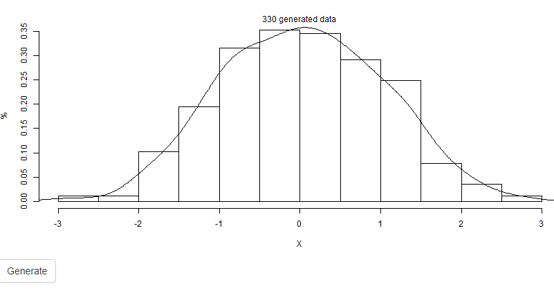

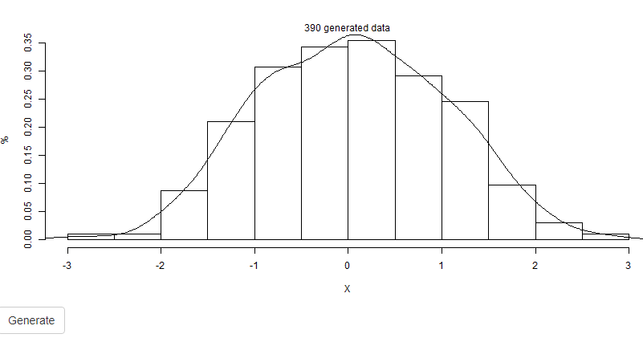

```r
ui<-bootstrapPage(
  plotOutput("plot"),
  actionButton("go", "Generate")
)

server<-function(input,output){

  rv <- reactiveValues()
  rv$numbers <- numeric()

  observeEvent(input$go,{
    rv$numbers <- c(rv$numbers,rnorm(10))
  })

  output$plot <- renderPlot({
    if (length(rv$numbers)==0) return(invisible(NULL)) # no data yet
    hist(rv$numbers, freq=FALSE, xlab="X", ylab="%",main="")
    lines(density(rv$numbers))
    mtext(paste(length(rv$numbers), "generated data"))
  })
}

shinyApp(ui=ui,server=server)
```

Note that `renderPlot` is executed when `rv$numbers` change.

### Example 2: Enter a passowrd

- Once the password is typed, check it by pressing a button.
- When 3 attempts are achieved without success, the button must be disabled and coloured in red.
- If the password is correct the button must be disabled and coloured in green.
- The number of attempts will be stored in a reactive element (`reactiveValues`).

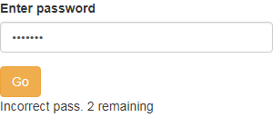

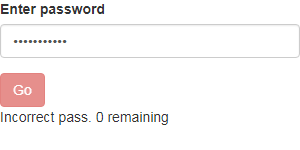

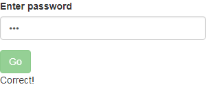

```r
library(shinyBS)
pass<-"123"

ui<-bootstrapPage(
  passwordInput("idpass","Enter password",""),
  bsButton("idbutton", "Go"),
  uiOutput("result")
)

server<-function(input,output,session){
  # iniciate number of attempts to 3
  rv <- reactiveValues(attempts=3)
  # do something when check buttonis pressed
  observeEvent(input$idbutton,{
    if (input$idpass == "") # no attempts yet
      updateButton(session,"idbutton",style="info")
    if (input$idpass!="" & input$idpass!=pass){ # incorrect password
      rv$attempts<<-rv$attempts-1
      if (rv$attempts == 0){ # no attempts remaining
        updateButton(session,"idbutton",style="danger",disabled=TRUE)
      } else { # only 1 remaining attempt
        updateButton(session,"idbutton",style="warning",disabled=FALSE)
      }
    }
    if (input$idpass==pass){
      updateButton(session,"idbutton",style="success",disabled=TRUE)
    }
  })

  output$result<-renderUI({
    if (input$idbutton==0) return(invisible(NULL))
    isolate({
      if (input$idpass!="" & input$idpass!=pass)
        return(paste("\n\nIncorrect pass. ",rv$attempts,"remaining"))
      if (input$idpass=="")
        return("\n\nEnter pass")
      if (input$idpass==pass){
        return("\n\nCorrect!")
      }
    })
  })
}

shinyApp(ui=ui,server=server)
```

### Toogle, show, hide, disable

- The **`shinyjs`** package, among other features, allows:
  - Hide/Show form widgets (`hide`, `show`, `toggle`)
  - Enable or disable buttons or other input widgets (`disable`)
- It is available on CRAN:

```r
install.packages(shinyjs)
```

- For more info, visit its [website](http://daattali.com/shiny/shinyjs-demo/).

### Example 1. Buttons (hide, show, toggle)

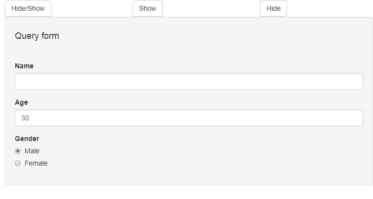

**UI**

```r
ui <- fluidPage(

  useShinyjs(), # Set up shinyjs

  fluidRow(
    column(4, actionButton("btntoggle",
                           "Hide/Show")),
    column(4, actionButton("btnshow", "Show")),
    column(4, actionButton("btnhide", "Hide"))
  ),

  hidden(
    wellPanel(id="elem",
      h4("Query form"),
      hr(),
      textInput("name", "Name", ""),
      numericInput("age", "Age", 30),
      radioButtons("gender", "Gender",
                   c("Male", "Female"))
    )
  )
)
```

**Server**

```r
server <- function(input, output) {

  observeEvent(input$btntoggle, {
    shinyjs::toggle("elem", TRUE, "fade")
  })

  observeEvent(input$btnshow, {
    shinyjs::show("elem", TRUE, "slide")
  })

  observeEvent(input$btnhide, {
    shinyjs::hide("elem", FALSE)
  })

}
```

### Example 2. Password

1. Make the app visible only if the password is correct.
2. Once the correct password is introduced the password input widget and the check button must disapear

```r
ui <- fluidPage(

  useShinyjs(),

  div(id="passScreen",
    passwordInput("pass","Password",""),
    actionButton("check","Check")
  ),

  shinyjs::hidden(
    div(id="myapp",
      titlePanel("Hello Shiny!"),
      sidebarLayout(
        sidebarPanel(
          sliderInput("obs","Number obs.",
              min=1,max=1000,value=500)
        ),
        mainPanel(
          plotOutput("distPlot")
        )
      )
    )
  )
)
```

```r
server <- function(input, output) {

  observeEvent(input$check, {
    if (input$pass=='123'){
      shinyjs::show("myapp", FALSE)
      shinyjs::hide("passScreen", FALSE)
    } else {
      shinyjs::hide("myapp", FALSE)
      shinyjs::show("passScreen", FALSE)
    }
  })

  output$distPlot <- renderPlot({
    hist(rnorm(input$obs))
  })

}
```

[Try it here](http://apps.datarus.eu/cursShinyEnglish/Bloque4Password/)

### Example 3. Body mass index

- You can enter either weight and height or body mass index (bmi).
- If user enter height and weight, bmi input widgets must be disabled but visible and updated according to bmi formula (weight/height^2)
- If user enter bmi, height and weight input widgets must be hidden.

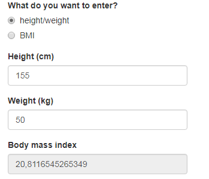

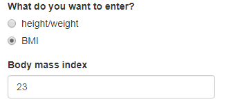

```r
library(shinyjs)

ui <- fluidPage(
  useShinyjs(),
  radioButtons("what","What do you want to enter?",
               c("height/weight"=1, "BMI"=2)),
  numericInput("height","Height (cm)",NA),
  numericInput("weight","Weight (kg)",NA),
  numericInput("bmi","Body mass index",NA)
)

server <- function(input, output, session) {
  observe({
    if (input$what==1){
      shinyjs::disable("bmi", FALSE)
      updateNumericInput(session, "bmi",
          value=input$weight/(input$height/100)^2)
      shinyjs::show("height", FALSE)
      shinyjs::show("weight", FALSE)
    } else {
      shinyjs::enable("bmi", FALSE)
      shinyjs::hide("height", FALSE)
      shinyjs::hide("weight", FALSE)
    }
  })
}

shinyApp(ui, server)
```

Exercise

### Exercise

From the app created in part IV:

- Add a password that be hidden once the pass is correct (123)

Try it [here](http://apps.datarus.eu/cursShinyEnglish/EjercicioBloque5)